# Radioactive decay: types, decay laws, and half-life

Dr. Ahmad Redaa

2025-09-08

# Radioactive Decay

- Definition of Radioactive Decay
- How radioactive decay is fundamental for radiometric dating?
- What is make radioavtive decay a usufel chronometer tool?

# Types of Radioactive Decay

- Alpha Decay
- Beta Decay
- Gamma Decay
- Electron Capture
- Spontaneous Fission

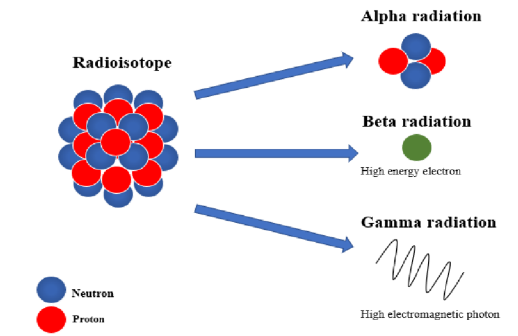

Types of radioactive decays, Source: [Stoian, A.I (2023)](https://intapi.sciendo.com/pdf/10.2478/kbo-2023-0080)

# Alpha Decay

**Definition:**  
- **Alpha decay** occurs when an unstable nucleus emits an alpha particle, composed of 2 protons and 2 neutrons, forming a new element.

**Key Characteristics:**  
- **Alpha Particle:** 2 protons and 2 neutrons (Helium-4 nucleus).  
- **Atomic Number:** Decreases by 2 (e.g., $^{238}_{92}\text{U}$ → $^{234}_{90}\text{Th}$).  
- **Mass Number:** Decreases by 4.

**Example:**  
- **$^{238}_{92}\text{U}$ → $^{234}_{90}\text{Th}$ + $^{4}_{2}\text{He}$**

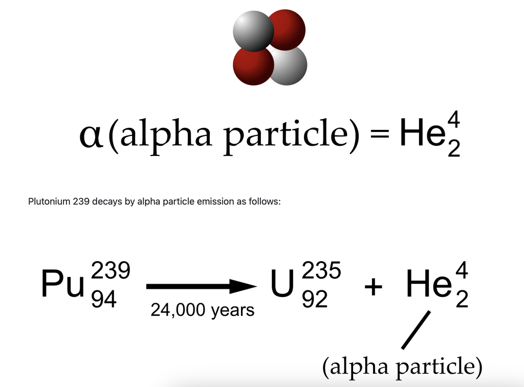

Source: [https://www.atomicarchive.com](https://www.atomicarchive.com/science/physics/alpha-decay.html)

# Beta Decay

**Definition:**  
- **Beta decay** is a process in which a neutron in an unstable nucleus is transformed into a proton, or a proton is transformed into a neutron, accompanied by the emission of a beta particle (electron or positron).

**Key Characteristics:**  
- **Beta-minus Decay:** Neutron → Proton + Electron + Antineutrino.  
- **Beta-plus Decay (Positron Emission):** Proton → Neutron + Positron + Neutrino.

[figure not shown]

Types of beta decay, Source: [https://www.sciencefacts.net/](https://www.sciencefacts.net/beta-decay.html)

# Beta-minus Decay (β⁻ Decay)

**Process:**  
- A **neutron** in the nucleus is converted into a **proton**.  
- This results in the emission of an **electron** (beta particle) and an **antineutrino**.

**Effect on Atomic Number:**  
- The atomic number **increases by 1**.  
- The mass number remains unchanged.

**Example:**  
- **Potassium-40 (K-40) → Calcium-40 (Ca-40) + Beta Particle (e-)**

$$^{40}_{19}\text{K} \rightarrow ^{40}_{20}\text{Ca} + \text{e}^{-} +
\bar{\nu}_e$$

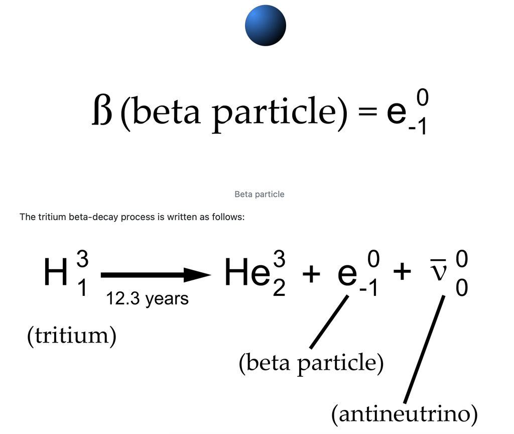

Source: [https://www.atomicarchive.com](https://www.atomicarchive.com/science/physics/beta-decay.html)

# Beta-plus Decay (β⁺ Decay) or Positron Emission

**Process:**  
- A **proton** in the nucleus is converted into a **neutron**.  
- This results in the emission of a **positron** (positive beta particle) and a **neutrino**.

**Effect on Atomic Number:**  
- The atomic number **decreases by 1**.  
- The mass number remains unchanged.

**Example:**  
- **Potassium-40 (K-40) → Argon-40 (Ar-40) + Positron (e+)**

$$^{40}_{19}\text{K} \rightarrow ^{40}_{18}\text{Ar} + \text{e}^{+} +
\nu_e$$

# Gamma Decay

**Process:**  
- **Gamma decay** occurs when an unstable nucleus releases excess energy by emitting a **gamma photon (γ)**.  
- This process follows other types of decay, like alpha or beta decay, when the nucleus is left in an excited state.

**Effect on Nucleus:**  
- The **atomic number** and **mass number** of the nucleus remain unchanged.  
- The nucleus moves from a higher energy state to a lower, more stable energy state.

**Example:**  
- **Cobalt-60 (Co-60) → Cobalt-60 (Co-60) + Gamma Photon (γ)**  
- Cobalt-60 undergoes gamma decay to release energy after beta decay, transitioning from an excited state to a more stable state.

$$^{60}_{27}\text{Co}^* \rightarrow ^{60}_{27}\text{Co} + \gamma$$

**Note:**  
- Gamma rays are highly penetrating and require dense materials, like lead, for shielding. They are a common form of high-energy radiation in both natural and artificial radioactive processes.

# Electron Capture

**Process:**  
- **Electron capture** occurs when an **electron** from the innermost orbital of an atom is captured by the nucleus.  
- This electron combines with a **proton** to form a **neutron** and a **neutrino**.

**Effect on Nucleus:**  
- The **atomic number** decreases by 1, while the **mass number** remains unchanged.  
- The nucleus transforms into a different element, but the overall mass of the nucleus remains the same.

**Example:**  
- **Potassium-40 (K-40) + Electron → Argon-40 (Ar-40) + Neutrino (νₑ)**  
- In this process, Potassium-40 captures an electron and becomes Argon-40, emitting a neutrino.

$$^{40}_{19}\text{K} + e^{-} \rightarrow ^{40}_{18}\text{Ar} + \nu_e$$

**Note:**  
- Electron capture often occurs in electron-rich environments and is an alternative decay mode to beta-plus decay.  
- The emitted neutrino carries away the excess energy and momentum from the reaction.

# Branching Decay

- Some isotopes can decay via two or more pathways.
- Each pathway has its own branching ratio (probability).
- The sum of branching probabilities = 100%.

## Example

- Potassium-40 ( $^{40}_{19}K$ ) is unstable and decays through two main modes:

### **1. Beta-minus decay (89%)**

$$^{40}_{19}K \;\;\rightarrow\;\; ^{40}_{20}Ca + e^- + \bar{\nu}_e$$

- Produces stable **Calcium-40**
- Increases atomic number by 1

### **2. Electron capture (11%)**

*(with minor positron emission)*
$$^{40}_{19}K + e^- \;\;\rightarrow\;\; ^{40}_{18}Ar + \nu_e$$

- Produces stable **Argon-40**
- Decreases atomic number by 1

# Spontaneous Fission

**Spontaneous fission** is a type of radioactive decay where an atomic nucleus splits into two or more smaller nuclei, along with the release of energy and neutrons, without the influence of an external cause

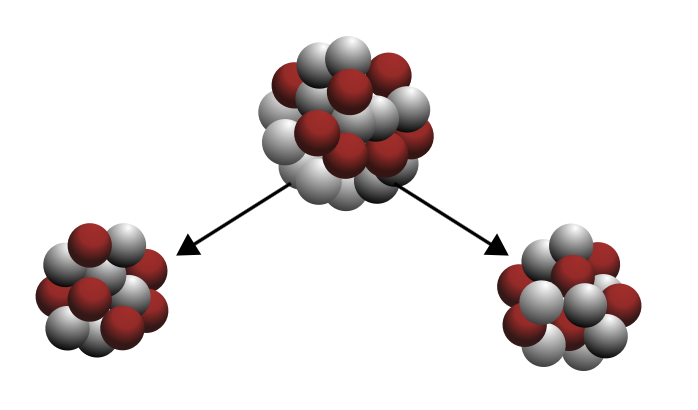

Source: [https://www.atomicarchive.com](https://www.atomicarchive.com/science/physics/spontaneous-fission.html)

**Process:**

- **Unprompted Division:**
  - An unstable heavy nucleus spontaneously splits into two or more smaller nuclei.
  - Occurs without external influence, driven by the nucleus’s intrinsic instability.
- **Energy Release:**
  - Significant amount of energy is released as kinetic energy of the fission fragments and radiation.
  - Energy is derived from the conversion of mass into energy ($E = mc^2$).

**General Nuclear Reaction:**

$$^{A}_{Z}\text{X} \rightarrow ^{A_1}_{Z_1}\text{Y} + ^{A_2}_{Z_2}\text{Z}
+ n_1 + n_2 + \ldots$$

where:  
- $^{A}_{Z}\text{X}$ is the parent nucleus.  
- $^{A_1}_{Z_1}\text{Y}$ and $^{A_2}_{Z_2}\text{Z}$ are the fission fragments.  
- $n_1, n_2, \ldots$ are the neutrons released.

**Characteristics:**

- **Less Common:**
  - Compared to alpha or beta decay, spontaneous fission is rarer due to the high energy barrier.
- **Heavy Elements:**
  - Common in very heavy elements like Uranium-238 ($^{238}\text{U}$) and Plutonium-240 ($^{240}\text{Pu}$).

**Example:**

- **Plutonium-240 ($^{240}\text{Pu}$)**

$$^{240}_{94}\text{Pu} \rightarrow ^{140}_{56}\text{Ba} +
^{94}_{38}\text{Kr} + 2n$$

- Plutonium-240 splits into Barium-140 and Krypton-94, with the emission of two neutrons.

# Deriving the Law of Radioactive Decay

## 1. Assumption

- The rate of decay of a radioactive substance is directly proportional to the number of undecayed nuclei $n$ at any time $t$.

- Expressed mathematically:
  $$\frac{dn}{dt} = -\lambda n$$
  where $\lambda$ is the decay constant.

## 2. Separation of Variables

- Rearrange the equation to separate variables $n$ and $t$:
  $$\frac{dn}{n} = -\lambda \, dt$$

## 3. Definite Integration

- Integrate both sides with limits $t = 0$ to $t$ for time, and $n = n_0$ to $n$ for the number of nuclei:
  $$\int_{n_0}^{n} \frac{1}{n} \, dn = \int_{0}^{t} -\lambda \, dt$$
- This yields:
  $$\ln \left( \frac{n}{n_0} \right) = -\lambda t$$

## 4. Solving for $n$

- Exponentiate both sides to solve for $n$:
  $$n = n_0 e^{-\lambda t}$$

# Half-Life

**Definition:**

- **Half-Life ($t_{1/2}$)** is the time required for half of the radioactive nuclei in a sample to decay.

**Key Points:**

- **Exponential Decay:**
  - Radioactive decay follows an exponential decay law, meaning the rate of decay is proportional to the number of remaining radioactive nuclei.
- **Formula:**

  $$N(t) = N_0 \cdot \left(\frac{1}{2}\right)^{\frac{t}{t_{1/2}}}$$

  where:
  - $N(t)$ is the number of radioactive nuclei at time $t$.
  - $N_0$ is the initial number of radioactive nuclei.
  - $t_{1/2}$ is the half-life of the radioactive substance.
  - $t$ is the elapsed time.
- **Decay Constant ($\lambda$):**

  The relationship between the half-life and the decay constant is:

  $$\lambda = \frac{\ln(2)}{t_{1/2}}$$

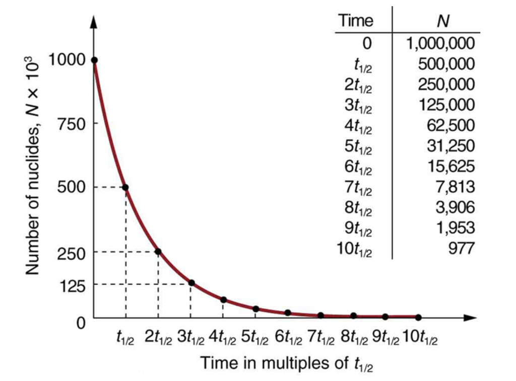

Radioactive decay reduces the number of radioactive nuclei over time., Source: [https://courses.lumenlearning.com](https://courses.lumenlearning.com/suny-physics/chapter/31-5-half-life-and-activity/)

**Example:**

- **Rubidium-Strontium (Rb-Sr) System**
  - **Rubidium-87 ($^{87}\text{Rb}$)** has a half-life of approximately 50 billion years (48.8 x ${10}^9$ years).
  - Used for dating geological samples and determining the age of rocks.
- **Carbon-14 ($^{14}\text{C}$)**
  - Half-life of about 5,730 years.
  - Used for dating archaeological samples.